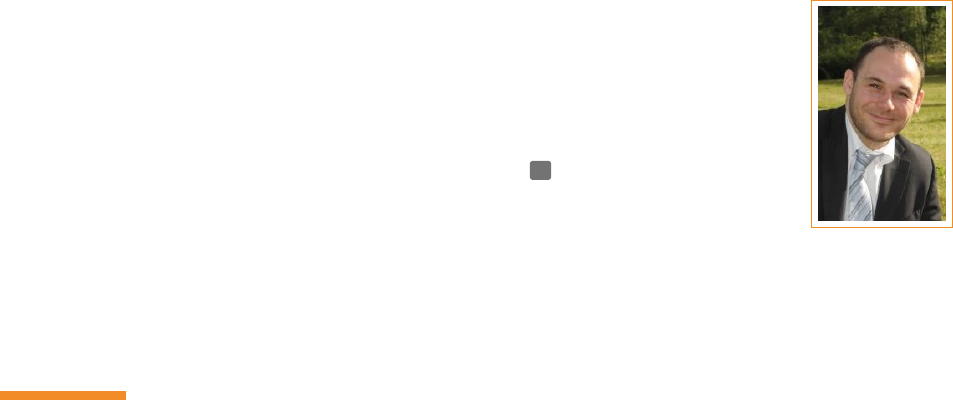

Raphaël Pinson

Open-Source Technologist

2, rue Favre

73000 Chambéry

 +33 (0) 673 524 413

 +33 (0) 456 753 683

 rpinson@gmail.com

www.linkedin.com/in/raphink

 www.github.com/raphink

Driving License

Freely you have received, freely give

Skills

Expert Skills

Debian and

Ubuntu

Systems

Debian/Ubuntu Packages, Creation and Administration of Package Repositories,

Build Farms (Debian buildd/sbuild/pbuilder), Automated Installations (Debian FAI)

Conguration

Management

Puppet

†

, MCollective

†

, Augeas

Development

Languages C, Perl, Python, Shell/Bash, Ruby, GNU

Make, Ada, Lua

Web HTML/XHTML, CSS, JavaScript, Ajax,

Jquery, PHP, Semantic Web

Frameworks Django, Google AppEngine, Google

Wave, Netvibes

Databases MySQL, PostgreSQL, NoSQL (GQL),

SPARQL

Formats XML/XPath, SGML, YAML/JSON,

RDF/RSS/FOAF

Methods Object Oriented Programming, MVC,

Unit Tests, UML

Source

Management

RCS/CVS, SVN, Bazaar, Git, Mercurial Tools Autotools, Cmake, Doxygen,

NaturalDocs, Trac, Gforge, Launchpad,

GitHub

Systems and Networks Administration

Web Apache, Lighttpd, Nginx, Varnish, Bind,

Squid, Dansguardian, VsFTPd

Monitoring BB4/Hobbit, Nagios, Munin, Cacti,

Simple Event Correlator (Sec)

Mail Postx, Exim, SSMTP Backup Amanda, BackupManager

Installation

and

Deployment

FAI, Kickstart, Reprepro, Cfengine,

Puppet

†

, MCollective

†

, Augeas

Networks DHCPd, VLANs, OpenVPN, Keepalived

Operating

Systems

GNU/Linux (Debian

†

, Ubuntu

,

RedHat), MacOS X, Windows, *BSD

Databases MySQL, PostgreSQL, SQLite,

BerkeleyDB

Virtualization Xen, VMWare, OpenVZ, LXC, NX Security SSL, PGP/GnuPG, OpenSSH

Oﬃce and tools

Oﬃce OpenOﬃce/LibreOﬃce, Microso

Oﬃce, Gimp, Inkscape

Project

Management

TaskJuggler, GanttProject

Productivity Mind Maps, GTD Wikis MediaWiki, Trac, MoinMoin

X, L

T

E

X, X

T

E

X, LuaT

E

X Touch Typing QWERTY & AZERTY

Developer

†

Contributor

1/3

[figure not shown]

Experience

IT Experience

..

2012

.

.

Instrastructure Developer & Trainer, Chambéry, Camptocamp.

Infrastructure Developer

– Infrastructure Automation with Puppet;

– Setting up cloud-based redundant solutions;

– Speaking at devop conferences;

– Technical trainings (Puppet, Augeas);

– Technical presales consulting.

..

2006

.

2012

Systems Engineer, ORNESS then Alten, Sophia Antipolis.

Consultant at France Télécom

– Administration of Cfengine, FAI and the soware package repository;

– Renewal and industrialization of the soware deployment system for Debian/Ubuntu;

– Management of the Gforge (collaborative development web interface) platform;

– Development of QA tools for systems and congurations policy compliance;

– Integration of the continuous integration platform (Hudson) with the Debian/Ubuntu soware

deployment system;

– Monitoring of the eet of servers;

– Writing of technical documentation.

..

2008

.

.

Developer, Augeas, Internet.

Development, bugx and documentation

– Writing of Augeas lenses;

– Coding in C;

– Improvement of autotools conguration;

– NaturalDocs Integration (documentation generator);

– International Conference Speaker (Belgium (FOSDEM)).

..

2005

.

.

Developer/Maintainer, Ubuntu, Internet.

Development, bugx and documentation

– Creation, maintainance and review of soware packages;

– Writing of technical documentation for developers;

– Maintainance of the QA system for soware package;

– Bug management;

– International Conference Speaker (Hungary, Germany (LinuxTag)).

..

2005

.

.

Open-Source Contributor, Various projects, Internet.

– Flammard Bible Bot: Google Wave Bot, a personal project written in Python/AppEngine;

– Ichthux: Creation and maintainance of a specialized Linux distribution based on Ubuntu;

– Byobu: contribution of scripts and patches in Python and Bash;

– CPAN Author: maintainer of several Perl modules on CPAN;

A

T

E

X packages on CTAN.

Other Experience

..

2009

.

.

Translator and Editor, La Colombe Calvary, Nice.

– Translation of English theology books into French;

A

T

E

X, X

E

T

E

X and LuaT

E

X;

– Publishing of books using on-demand publishing services (CreateSpace and Lulu).

..

July 2004

.

•

Blue Collar Internship, SNECMA, Moissy-Cramayel.

Assembled and equilibrated turbo reactors for planes

..

1999–2000

Certied First Responder, French Red Cross, Paris Suburbs.

Served in several volunteer missions as a paramedic

2/3

[figure not shown]

Education

..

2013

.

•

Puppet Trainer, PuppetLabs, Amsterdam.

Oﬃcial Training Partner for PuppetLabs’ courses (Puppet Fundamentals, Puppet Advanced, Extending

Puppet with Ruby)

..

2009

.

•

ITIL® v3 Foundation, EXIN, Sophia Antipolis.

Organization and eﬃciency of the Information System

..

2005

.

•

Student in Business Creation and Management, Créafort, Poitiers.

Accounting, Management, Marketing, Law

..

2005

.

•

Student in Pedagogy (‘Gestion Mentale’), IFGM, Bordeaux.

Pedagogy, Didacticism, Cognitive Psychology

..

2003–2005

Student in Mechanical Engineering,

École Nationale Supérieure de Mécanique et d’Aérotechnique (ENSMA), Poitiers.

Solid & Fluid Mechanics, Mathematics, Combusion & Propulsion, Materials Science, Automation,

Signal Processing, Computer Sciences, Management

..

2004

.

•

Licence, equivalent of a British Bsc, in Mechanics, Université de Poitiers, Poitiers.

Solid & Fluid Mechanics, Mathematics, Combusion & Propulsion, Materials Science, Automation,

Signal Processing, Computer Sciences, Management

..

2002–2003

Student in Chemistry, Université de Paris XI, Orsay.

Chemistry, Physics, Mathematics

..

2000-2002

Student in Medicine (PCEM1), Université de Paris XI, Orsay.

Biology, Chemistry, Biochemistry, Physics, Anatomy, Histology, Physiology, Law

..

2000

.

•

Baccalauréat, equivalent of British A Level, Lycée Blaise Pascal, Orsay, with distinction

‘mention bien’.

Certications

..

2013

.

•

Puppet Certied Developer, PuppetLabs, PCD0000011.

Puppet IT automation soware

..

2013

.

•

Puppet Certied Professional, PuppetLabs, PCP0000116.

Puppet IT automation soware

..

2009

.

•

ITIL® v3 Foundation Examination, EXIN055512.

Organization and eﬃciency of the Information System

Foreign Languages

French Native Mother Tongue

English Fluent Daily practice, conferences given in English

Spanish Good Level Occasional practice

German Good Level Studied 9 years in school

Personal interests

Music Clarinet, piano, organ, saxophone

Sports Hiking, sailing, golf, climbing

Contributions Wikipedia, OpenStreetMap

Memberships President of the cultural association ‘la Colombe de Savoie’

Ubuntu member

Others Travels, reading

3/3